# RMSC5102 2020S Exercise for General Simulation

LEUNG Man Fung, Heman

# Random variable generation

## Exercise

Consider the quadratic random variable $X$ with pdf:
$$\begin{aligned}
f_X(x) &=
\left\{
\begin{array}{ll}
\frac{3}{64} (x-2)^2 &, x \in [-2,2] \\
0 &, x \notin [-2,2]
\end{array}
\right. \\
\end{aligned}$$
Propose an inverse transform algorithm and acceptance-rejection algorithm using $Y \sim N(0,1)$ to generate $X$
(modified from RMSC4001 2014S final Q3)

## Solution

Note that for $x \in [-2,2]$,
$$\begin{aligned}
F_X(x) &= \int_{-2}^x \frac{3}{64} (t-2)^2 dt \\
&= \left[ \frac{1}{64} (t-2)^3 \right]_{-2}^x \\
&= \frac{1}{64} (x-2)^3 +1 \\
U = \frac{1}{64} (X-2)^3 +1 \implies (X-2)^3 &= 64U-64 \\
X &= (64U-64)^{\frac{1}{3}} +2
\end{aligned}$$
Hence the inverse transform algorithm is as follows:
1) Generate $U \sim U(0,1)$
2) Set $X = (64U-64)^{\frac{1}{3}} +2$

We verify the algorithm with the following R implementation:

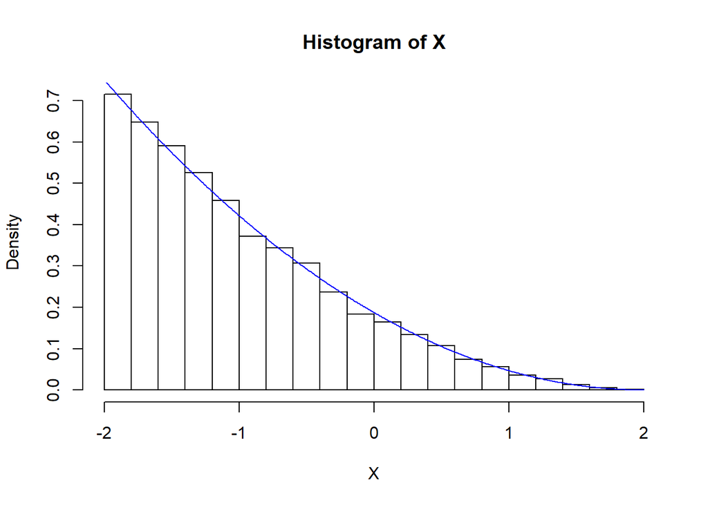

```r
n = 10000
U = runif(n)
X = -(64-64*U)^(1/3)+2 #R cannot handle cube root of negative
hist(X, freq=F)
px = seq(-2,2,by=0.01)
py = 3/64*(px-2)^2
lines(px, py, col="blue") #add target pdf of X
```

For the acceptance-rejection algorithm, note that
$$\begin{aligned}
f_Y(y) &= \frac{1}{\sqrt{2\pi}} e^{-\frac{1}{2} y^2} \\
\frac{f_X(y)}{f_Y(y)} &=
\left\{
\begin{array}{ll}
\frac{3\sqrt{2\pi}}{64} (y-2)^2 e^{\frac{1}{2} y^2} &, y \in [-2,2] \\
0 &, y \notin [-2,2]
\end{array}
\right. \\
c = \max_y \frac{f_X(y)}{f_Y(y)} &= \frac{f_X(-2)}{f_Y(-2)} = \frac{3 e^2 \sqrt{2\pi}}{4}
\end{aligned}$$
since $(y-2)^2$ is decreasing for $y \in [-2,2]$ while $e^{\frac{1}{2} y^2}$ is maximized at $y=-2$ and $y=2$. Hence the algorithm is as follows:
1) Generate $Y \sim N(0,1)$
2) If $Y \notin [-2,2]$, return to step 1 (due to different support)
3) Generate $U \sim U(0,1)$
4) If $U \leq \frac{1}{c} \cdot \frac{f_X(Y)}{f_Y(Y)} = \frac{1}{16} (Y-2)^2 e^{\frac{1}{2} Y^2-2}$, set $X=Y$. Otherwise return to step 1

We verify the algorithm with the following R implementation:

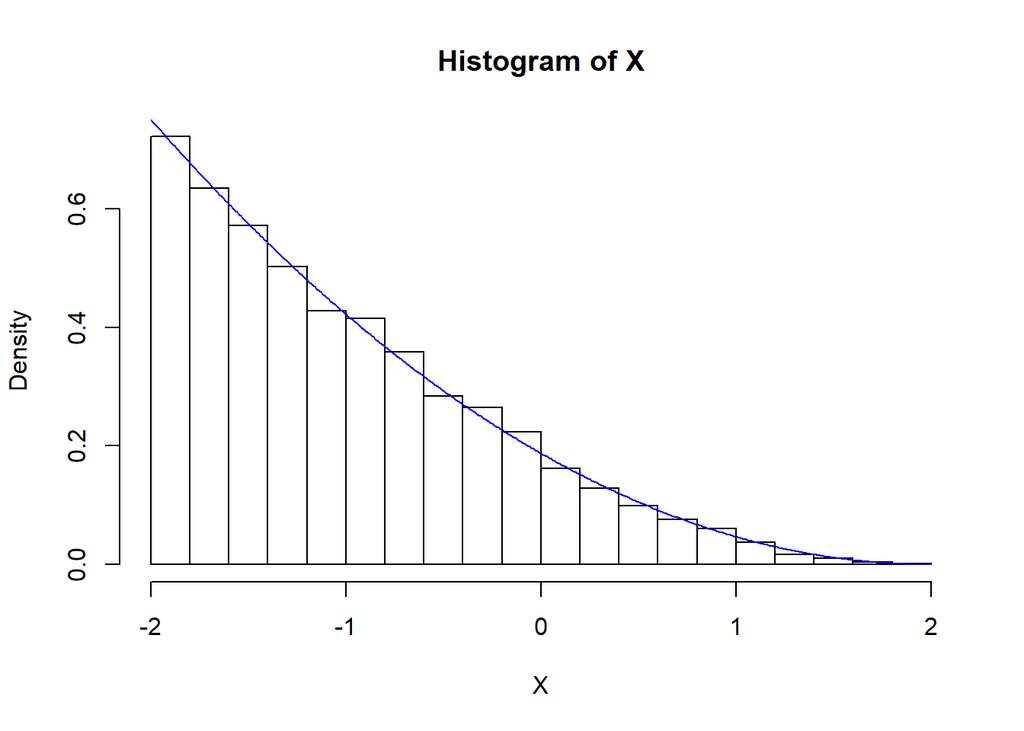

```r
# Use result of the above
X = vector(length=n)
for (i in 1:n)
{
  repeat
  {
    repeat
    {
      Y = rnorm(1)
      if (Y >= -2 && Y <= 2)
        break
    }
    U = runif(1)
    if (U <= 1/16 *(Y-2)^2 *exp(0.5*Y^2-2))
    {
      X[i] = Y
      break
    }
  }
}
hist(X, freq=F)
lines(px, py, col="blue")
```